# Genetic clustering

In this script we will look at some descriptive statistics from the genetic PCA, previously done in Plink, and Admixture analysis. The steps to create the genetic PCA were as following:

- Remove of missing genotype data.
- LD pruning using a window size of 10kb and a VIF of 2.
- Only 1000Genomes samples were used to create the PCA, and our samples were projected there.
- A total of 50 PCs were extracted

## Preliminaries

Calling libraries and datasets

```r
library(ggplot2)
library(dplyr)
library(GGally)
library(ggpubr)
library(caret)
library(pophelper)
library(gridExtra)

setwd('..')
path <- getwd()
setwd(paste(path, "/Results/GenPCA", sep = ""))
pca.eigenval <- read.csv("PCA.eigenval", sep = "", header = F)
pca.eigenvec <- read.csv("PCA.eigenvec", sep = "", header = F)
PCnames      <- sprintf("PC%s",seq(1:50))
colnames(pca.eigenvec) <- c("FID", "IID", PCnames)

setwd(paste(path, "/Results/MergeGeno/Merge1000G", sep = ""))
pops <- read.csv("integrated_call_samples_v3.20130502.ALL.panel", sep = "")
colnames(pops)[1] <- "IID"

setwd(paste(path, "/Results/Admixture", sep = ""))
admix <- readQ("Merge1000Gsamples.6.Q")
#Removing duplicates
admix[[1]]   <- admix[[1]][!duplicated(pca.eigenvec$IID), ]
pca.eigenvec <- pca.eigenvec[!duplicated(pca.eigenvec$IID), ]

rownames(admix[[1]]) <- pca.eigenvec$IID
```

## Data cleaning

Creating new columns to plot 1000Genomes pops against our samples more easily.

```r
pca.eigenvec$FID <- as.character(pca.eigenvec$FID)
for(i in 1:nrow(pca.eigenvec)){
  if(pca.eigenvec$IID[i] %in% pops$IID){
    ind <- match(pca.eigenvec$IID[i], pops$IID)
    pca.eigenvec$FID[i] <- as.character(pops$pop[ind])
  }
}
pca.eigenvec$FID <- as.factor(pca.eigenvec$FID)
pca.eigenvec$pop <- pca.eigenvec$FID
pca.eigenvec$pop[!(pca.eigenvec$FID %in% pops$pop)] <- "ADAPT"
pca.eigenvec$pop <- droplevels(pca.eigenvec$pop)

pca.eigenvec$super_pop <- as.character(pca.eigenvec$pop)
for(i in 1:nrow(pca.eigenvec)){
  if(pca.eigenvec$IID[i] %in% pops$IID){
    ind <- match(pca.eigenvec$IID[i], pops$IID)
    pca.eigenvec$super_pop[i] <- as.character(pops$super_pop[ind])
  }
}
pca.eigenvec$super_pop <- as.factor(pca.eigenvec$super_pop)
```

```r
pca.eigenvec[,3:52] <- t(c(as.matrix(pca.eigenval)) * t(as.matrix(pca.eigenvec[,3:52])))
```

## Descriptive and exploratory analyses

Some summary stats

```r
summary(pca.eigenvec[,c(1,2,53,54)])
```

```
##        FID            IID            pop       super_pop
##  ADAPT   :2538   120018 :   1   ADAPT  :5124   ADAPT:5124
##  SA      : 200   120036 :   1   GWD    : 113   AFR  : 661
##  GWD     : 113   120038 :   1   YRI    : 108   AMR  : 347
##  UIUC2013: 112   131001 :   1   IBS    : 107   EAS  : 504
##  YRI     : 108   131002 :   1   TSI    : 107   EUR  : 503
##  IBS     : 107   131003 :   1   CHS    : 105   SAS  : 489
##  (Other) :4450   (Other):7622   (Other):1964
```

PCA screeplot

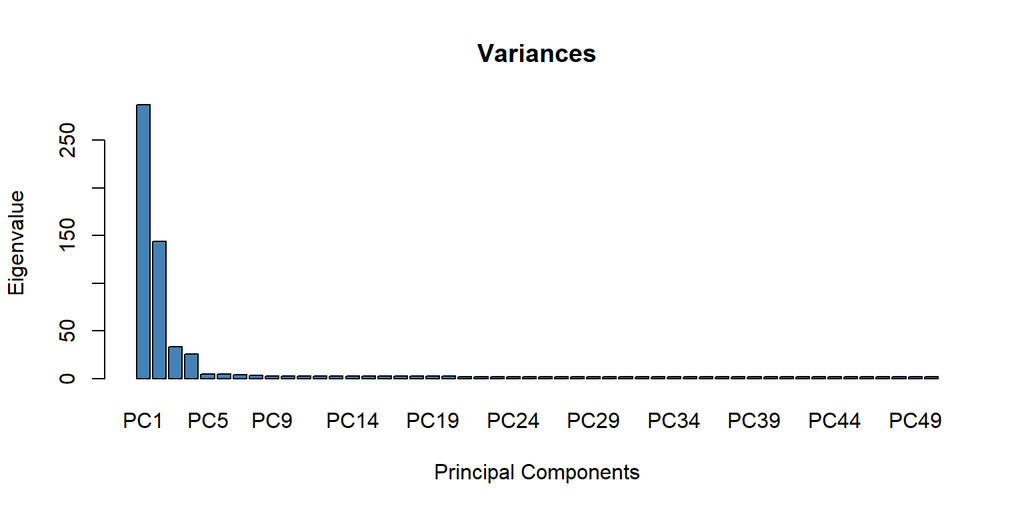

```r
barplot(c(as.matrix(pca.eigenval)), names.arg=PCnames,
       main = "Variances",
       xlab = "Principal Components",
       ylab = "Eigenvalue",
       col = "steelblue")
```

Looking at the 1000Genomes populations:

| POP | SUPER POP | Description |
| --- | --- | --- |
| FIN | EUR | Finnish in Finland |
| CHS | EAS | Han Chinese South |
| GBR | EUR | British from England and Scotland |
| PUR | AMR | Puerto Rican in Puerto Rico |
| CLM | AMR | Colombian in Medellin, Colombia |
| MXL | AMR | Mexican Ancestry in Los Angeles, California |
| TSI | EUR | Toscani in Italia |
| LWK | AFR | Luhya in Webuye, Kenya |
| JPT | EAS | Japanese in Tokyo, Japan |
| IBS | EUR | Iberian populations in Spain |
| PEL | AMR | Peruvian in Lima, Peru |
| CDX | EAS | Chinese Dai in Xishuangbanna, China |
| YRI | AFR | Yoruba in Ibadan, Nigeria |
| KHV | EAS | Kinh in Ho Chi Minh City, Vietnam |
| ASW | AFR | African ancestry in Southwest USA |
| ACB | AFR | African Caribbean in Barbados |
| CHB | EAS | Han Chinese in Beijing, China |
| GIH | SAS | Gujarati Indians in Houston, Texas |
| GWD | AFR | Gambian in Western Division, The Gambia |
| PJL | SAS | Punjabi in Lahore,Pakistan |
| MSL | AFR | Mende in Sierra Leone |
| BEB | SAS | Bengali in Bangladesh |
| ESN | AFR | Esan in Nigeria |
| STU | SAS | Sri Lankan Tamil in the UK |
| ITU | SAS | Indian Telugu in the UK |
| CEU | EUR | Utah residents with Northern and Western European ancestry from the CEPH collection |

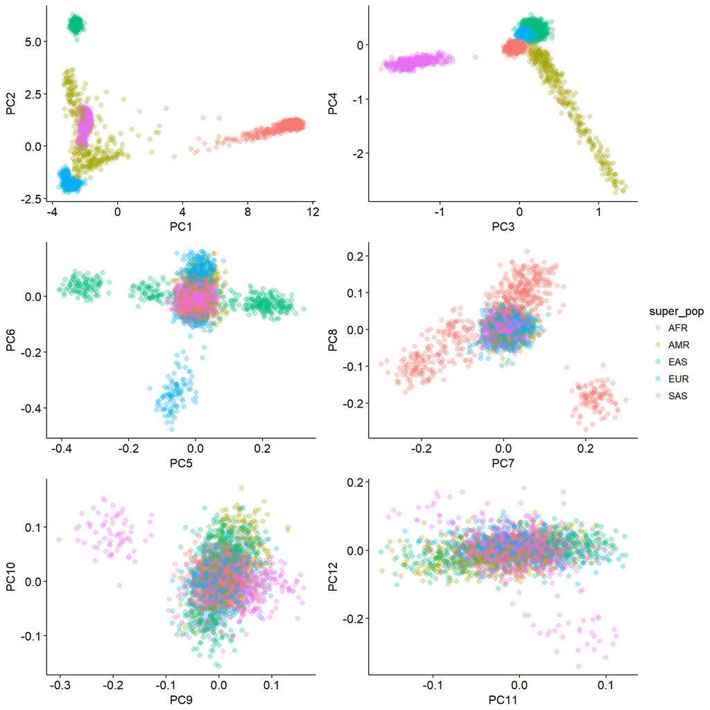

```r
plothap <- function(dat, x1, y1)
{
  p1 <- ggplot(dat, aes_string(x = x1, y = y1, color = "super_pop")) +
            geom_point(alpha = 0.3, size = 2) + theme_pubr()
  p1 <- ggpar(p1, palette = "jama")
  return(p1)
}

p1 <- plothap(filter(pca.eigenvec, super_pop != "ADAPT"), "PC1", "PC2")
p2 <- plothap(filter(pca.eigenvec, super_pop != "ADAPT"), "PC3", "PC4")
p3 <- plothap(filter(pca.eigenvec, super_pop != "ADAPT"), "PC5", "PC6")
p4 <- plothap(filter(pca.eigenvec, super_pop != "ADAPT"), "PC7", "PC8")
p5 <- plothap(filter(pca.eigenvec, super_pop != "ADAPT"), "PC9", "PC10")
p6 <- plothap(filter(pca.eigenvec, super_pop != "ADAPT"), "PC11", "PC12")

ggarrange(p1, p2, p3, p4, p5, p6, nrow = 3, ncol = 2,
          common.legend = TRUE, legend = "right",
          align = "v")
```

We can plot our samples with the centroid of the HapMap pops indicated.

```r
meanshap <- dplyr::filter(pca.eigenvec, pop != "ADAPT") %>% dplyr::group_by(pop, super_pop) %>%
            dplyr::select(contains("PC")) %>% summarise_all(funs(mean))
```

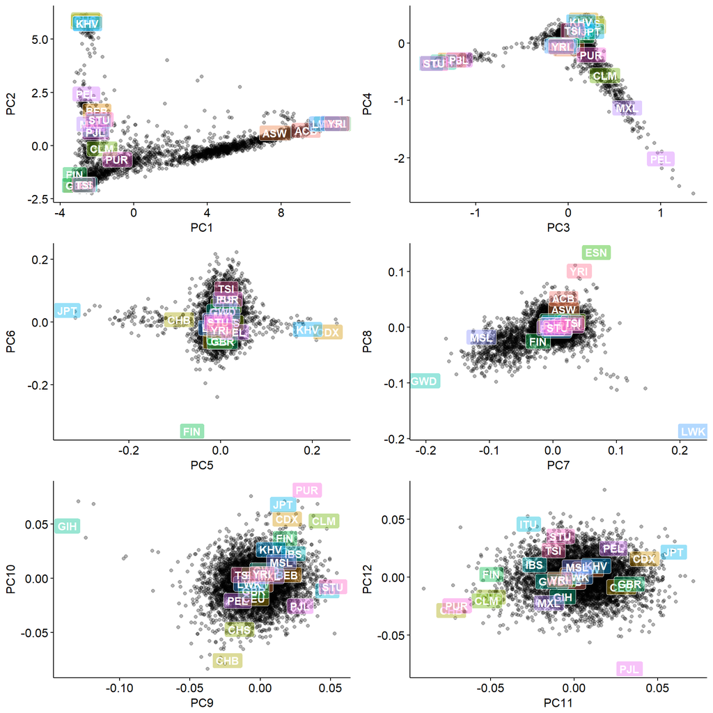

```r
plothapsamp <- function(dat1, dat2, x1, y1)
{
  p1 <- ggplot(dat1, aes_string(x = x1, y = y1, label = "pop")) +
          geom_point(data = dat2,
                     aes_string(x = x1, y = y1), alpha = 0.3) +
          geom_label(aes(fill = pop), colour = "white", fontface = "bold", alpha = 0.4) +
          theme_pubr(legend = "none")
  p1 <- ggpar(p1, palette = "jama")
  return(p1)
}

p1 <- plothapsamp(meanshap, filter(pca.eigenvec, pop == "ADAPT"), "PC1", "PC2")
p2 <- plothapsamp(meanshap, filter(pca.eigenvec, pop == "ADAPT"), "PC3", "PC4")
p3 <- plothapsamp(meanshap, filter(pca.eigenvec, pop == "ADAPT"), "PC5", "PC6")
p4 <- plothapsamp(meanshap, filter(pca.eigenvec, pop == "ADAPT"), "PC7", "PC8")
p5 <- plothapsamp(meanshap, filter(pca.eigenvec, pop == "ADAPT"), "PC9", "PC10")
p6 <- plothapsamp(meanshap, filter(pca.eigenvec, pop == "ADAPT"), "PC11", "PC12")

ggarrange(p1, p2, p3, p4, p5, p6,
          nrow = 3, ncol = 2,
          align = "v")
```

We can also plot our Irish, Polish, Italian, and Portuguese samples. Clearly there is a north-south structure in Europe, captured also by our samples.

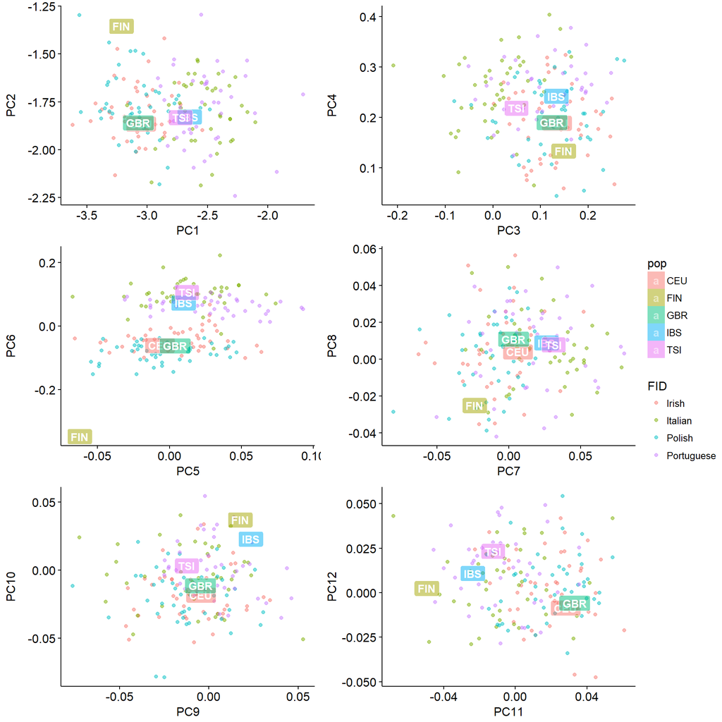

```r
plothapgroup <- function(dat1, dat2, x1, y1)
{
  p1 <- ggplot(dat1, aes_string(x = x1, y = y1, label = "pop")) +
          geom_point(data = dat2, aes_string(x = x1, y = y1, color = "FID"), alpha = 0.5) +
          geom_label(aes(fill = pop), colour = "white", fontface = "bold", alpha = 0.5) +
          theme_pubr()
  p1 <- ggpar(p1, palette = "jama")
  return(p1)
}

eurhap  <- filter(meanshap, super_pop == "EUR")
eursamp <- filter(pca.eigenvec, FID == "Italian" | FID == "Polish" | FID == "Irish" |
                                FID == "Portuguese")

p1 <- plothapgroup(eurhap, eursamp, "PC1", "PC2")
p2 <- plothapgroup(eurhap, eursamp, "PC3", "PC4")
p3 <- plothapgroup(eurhap, eursamp, "PC5", "PC6")
p4 <- plothapgroup(eurhap, eursamp, "PC7", "PC8")
p5 <- plothapgroup(eurhap, eursamp, "PC9", "PC10")
p6 <- plothapgroup(eurhap, eursamp, "PC11", "PC12")


ggarrange(p1, p2, p3, p4, p5, p6,
          nrow = 3, ncol = 2,
          common.legend = TRUE, legend = "right",
          align = "v")
```

Finally, let’s take a look at the admixture analysis. Based on visual inspection, these are the approximate cluster by geography associations

| Cluster | POP |
| --- | --- |
| 1 | NEU |
| 2 | EAS |
| 3 | SAS |
| 4 | SEU |
| 5 | AMR |
| 6 | AFR |

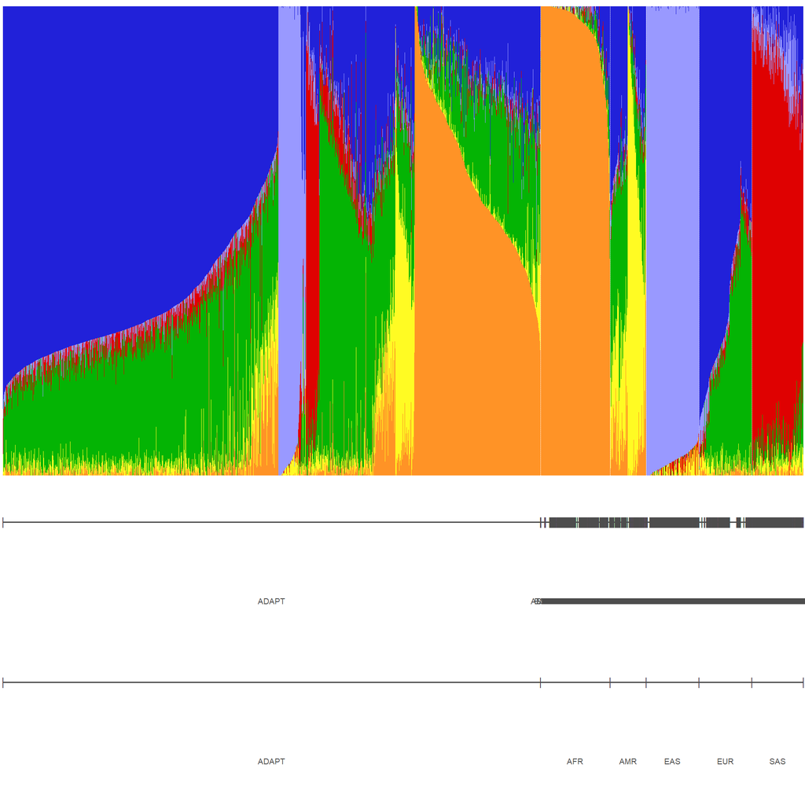

```r
groups <- pca.eigenvec[,c(53, 54),drop=FALSE]
groups <- data.frame(lapply(groups, as.character), stringsAsFactors=FALSE)
#This function exports the graph. It is possible to show it here?
p1 <- plotQ(admix, returnplot=T, exportplot=F, quiet=T, basesize=11, showsp=F,
            grplab=groups, ordergrp=TRUE, selgrp="super_pop", sortind="all")
plot(p1$plot[[1]])
```

## Clustering

For the clustering approach, we’ll use the super_pop variables from 1000Genomes. I’ll use the reference samples as training, with a 5-fold cross-validation, and predict the values of our samples.

```r
set.seed(10)
train <- pca.eigenvec %>% filter(super_pop != "ADAPT")
train <- droplevels(train)
test  <- pca.eigenvec %>% filter(super_pop == "ADAPT")
test  <- droplevels(test)

# 5-fold repeated cross-validation
fitControl <- trainControl(method = "repeatedcv", number = 5, repeats = 5)
svm.fit    <- train(super_pop ~ PC1 + PC2 + PC3 + PC4 + PC5, method = 'svmRadial',
                     trControl = fitControl, data = train)

svm.fit
```

```
## Support Vector Machines with Radial Basis Function Kernel
##
## 2504 samples
##    5 predictor
##    5 classes: 'AFR', 'AMR', 'EAS', 'EUR', 'SAS'
##
## No pre-processing
## Resampling: Cross-Validated (5 fold, repeated 5 times)
## Summary of sample sizes: 2004, 2003, 2003, 2003, 2003, 2003, ...
## Resampling results across tuning parameters:
##
##   C     Accuracy   Kappa
##   0.25  0.9929688  0.9911219
##   0.50  0.9931281  0.9913228
##   1.00  0.9935281  0.9918282
##
## Tuning parameter 'sigma' was held constant at a value of 1.63901
## Accuracy was used to select the optimal model using the largest value.
## The final values used for the model were sigma = 1.63901 and C = 1.
```

```r
test$continent <- predict(svm.fit, test)
summary(test$continent)
```

```
##  AFR  AMR  EAS  EUR  SAS
## 1145  904  211 2739  125
```

Scatter plots of the predicted continent groups

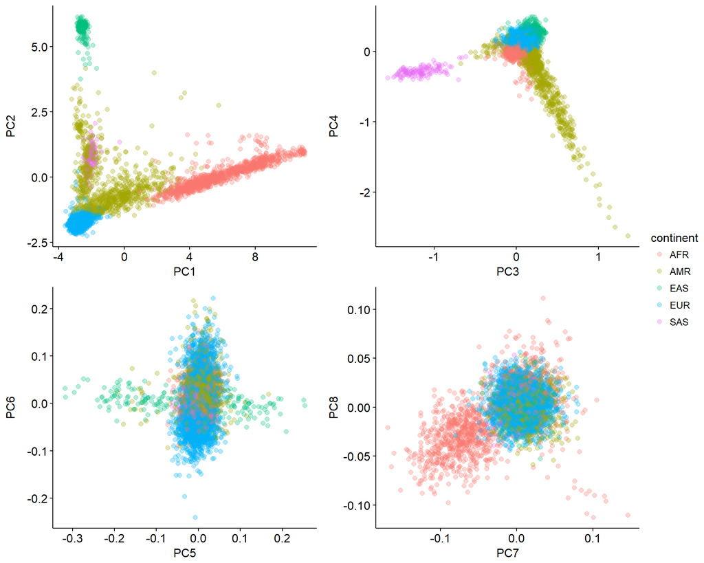

```r
plotcont <- function(dat, x1, y1)
{
  p1 <- ggplot(dat, aes_string(x = x1, y = y1, color = "continent")) +
            geom_point(alpha = 0.3, size = 2) + theme_pubr()
  p1 <- ggpar(p1, palette = "jama")
  return(p1)
}

p1 <- plotcont(test, "PC1", "PC2")
p2 <- plotcont(test, "PC3", "PC4")
p3 <- plotcont(test, "PC5", "PC6")
p4 <- plotcont(test, "PC7", "PC8")

ggarrange(p1, p2, p3, p4, nrow = 2, ncol = 2,
          common.legend = TRUE, legend = "right",
          align = "v")
```

```r
pca.eigenvec$Eur[pca.eigenvec$pop == "CEU" | pca.eigenvec$pop == "FIN" |
                 pca.eigenvec$pop == "GBR"] <- "NEU"
pca.eigenvec$Eur[pca.eigenvec$pop == "TSI" | pca.eigenvec$pop == "IBS"] <- "SEU"

set.seed(10)
train.eur <- pca.eigenvec %>% filter(super_pop == "EUR")
test.eur  <- filter(test, continent == "EUR")

# 5-fold repeated cross-validation
fitControl  <- trainControl(method = "repeatedcv", number = 5, repeats = 5)
svm.fit.eur <- train(Eur ~ PC1 + PC2 + PC3 + PC4 + PC5, method = 'svmRadial',
                     trControl = fitControl, data = train.eur)
svm.fit.eur
```

```
## Support Vector Machines with Radial Basis Function Kernel
##
## 503 samples
##   5 predictor
##   2 classes: 'NEU', 'SEU'
##
## No pre-processing
## Resampling: Cross-Validated (5 fold, repeated 5 times)
## Summary of sample sizes: 403, 402, 403, 402, 402, 403, ...
## Resampling results across tuning parameters:
##
##   C     Accuracy   Kappa
##   0.25  0.9172226  0.8302733
##   0.50  0.9212148  0.8389478
##   1.00  0.9212108  0.8391732
##
## Tuning parameter 'sigma' was held constant at a value of 0.2238566
## Accuracy was used to select the optimal model using the largest value.
## The final values used for the model were sigma = 0.2238566 and C = 0.5.
```

```r
test.eur$continent <- predict(svm.fit.eur, test.eur)
summary(test.eur$continent)
```

```
##  NEU  SEU
## 1569 1170
```

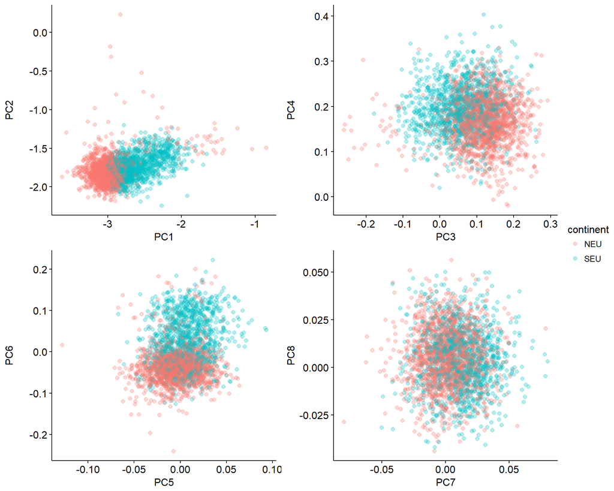

```r
p1 <- plotcont(test.eur, "PC1", "PC2")
p2 <- plotcont(test.eur, "PC3", "PC4")
p3 <- plotcont(test.eur, "PC5", "PC6")
p4 <- plotcont(test.eur, "PC7", "PC8")

ggarrange(p1, p2, p3, p4, nrow = 2, ncol = 2,
          common.legend = TRUE, legend = "right",
          align = "v")
```

```r
levels(test$continent) <- c("AFR", "AMR", "EAS", "EUR", "SAS", "NEU", "SEU")
test$continent[test$continent == 'EUR'] <- test.eur$continent
test$Eur <- NULL
test <- droplevels(test)
summary(test$continent)
```

```
##  AFR  AMR  EAS  SAS  NEU  SEU
## 1145  904  211  125 1569 1170
```

If we look at the clustering and the admixture proportions, we see this

```r
testadmix <- admix[[1]][rownames(admix[[1]]) %in% test$IID,]
meanstest <- testadmix %>% dplyr::group_by(test$continent) %>% summarise_all(funs(mean))
meanstest
```

```
## # A tibble: 6 x 7
##   `test$continent` Cluster1 Cluster2 Cluster3 Cluster4 Cluster5 Cluster6
##   <fct>               <dbl>    <dbl>    <dbl>    <dbl>    <dbl>    <dbl>
## 1 AFR               0.144     0.0140   0.0161  0.173     0.0144  0.638
## 2 AMR               0.293     0.0506   0.0383  0.292     0.191   0.134
## 3 EAS               0.00484   0.957    0.0158  0.00402   0.0156  0.00230
## 4 SAS               0.115     0.0497   0.722   0.0768    0.0294  0.00749
## 5 NEU               0.685     0.0137   0.0282  0.246     0.0216  0.00560
## 6 SEU               0.496     0.0163   0.0500  0.408     0.0147  0.0150
```

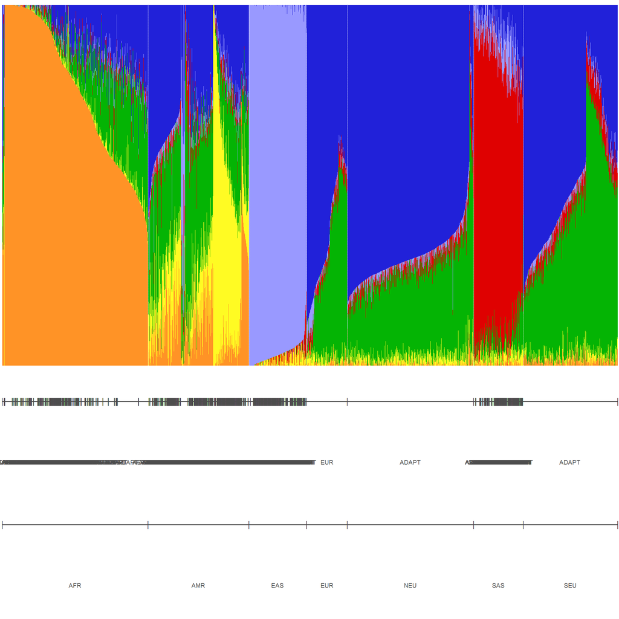

```r
groups$cont <- groups$super_pop
groups$cont[pca.eigenvec$IID %in% test$IID ] <- as.character(test$continent)

p1 <- plotQ(admix, returnplot=T, exportplot=F, quiet=T, basesize=11, showsp=F,
            grplab=groups[,2:3], ordergrp=TRUE, sortind="all", selgrp = "cont")
grid.arrange(p1$plot[[1]])
```

## Combining datasets

```r
setwd('..')
path <- getwd()
setwd(paste(path, "/Results/FacePCA", sep = ""))
coeffs   <- read.csv("cleancoeffs.csv")
```

```r
colnames(coeffs)[1] <- "IID"
total      <- merge(test, coeffs, by = "IID")
FacePCA    <- total[,61:147]
GenPCA     <- total[,3:52]
Covariates <- total[,c(1,2,56:60,54,55)]

PCnames <- sprintf("PC%s",seq(1:87))
colnames(FacePCA) <- PCnames

PCnames <- sprintf("PC%s",seq(1:50))
colnames(GenPCA) <- PCnames

MergedDat <- list(Covariates, FacePCA, GenPCA)

setwd('..')
path <- getwd()
setwd(paste(path, "/Results/MergedData", sep = ""))
save(MergedDat, file = "MergedDat.RData")
```